# chapter6 - Clustering

alfonso

May 1, 2016

# k-means 聚类

使用 iris 的数据来展示 k-means 聚类

```r
library(ggplot2)
iris2 <- iris
iris2$Species <- NULL # 去掉类别
(kmeans.result <- kmeans(iris2, 3)) # 聚3个类
```

```
## K-means clustering with 3 clusters of sizes 33, 21, 96
##
## Cluster means:
##   Sepal.Length Sepal.Width Petal.Length Petal.Width
## 1     5.175758    3.624242     1.472727   0.2727273
## 2     4.738095    2.904762     1.790476   0.3523810
## 3     6.314583    2.895833     4.973958   1.7031250
##
## Clustering vector:
##   [1] 1 2 2 2 1 1 1 1 2 2 1 1 2 2 1 1 1 1 1 1 1 1 1 1 2 2 1 1 1 2 2 1 1 1 2
##  [36] 1 1 1 2 1 1 2 2 1 1 2 1 2 1 1 3 3 3 3 3 3 3 2 3 3 2 3 3 3 3 3 3 3 3 3
##  [71] 3 3 3 3 3 3 3 3 3 3 3 3 3 3 3 3 3 3 3 3 3 3 3 2 3 3 3 3 2 3 3 3 3 3 3
## [106] 3 3 3 3 3 3 3 3 3 3 3 3 3 3 3 3 3 3 3 3 3 3 3 3 3 3 3 3 3 3 3 3 3 3 3
## [141] 3 3 3 3 3 3 3 3 3 3
##
## Within cluster sum of squares by cluster:
## [1]   6.432121  17.669524 118.651875
##  (between_SS / total_SS =  79.0 %)
##
## Available components:
##
## [1] "cluster"      "centers"      "totss"        "withinss"
## [5] "tot.withinss" "betweenss"    "size"         "iter"
## [9] "ifault"
```

```r
table(iris$Species, kmeans.result$cluster)
```

```
##
##               1  2  3
##   setosa     33 17  0
##   versicolor  0  4 46
##   virginica   0  0 50
```

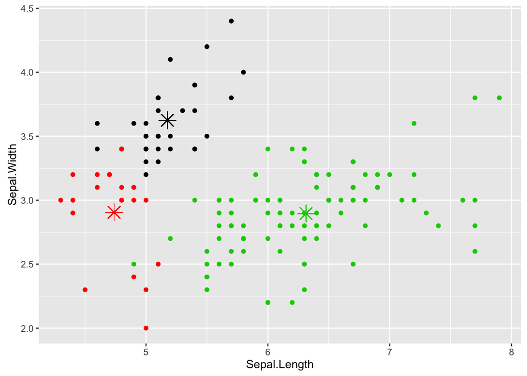

```r
extended_points <- cbind(kmeans.result$centers[,c("Sepal.Length", "Sepal.Width")], seq_along(kmeans.result$centers[,1]))
colnames(extended_points)[3] <- "colour"
add_points <- function(item) {
  geom_point(data = NULL, aes_string(x = item[1], y = item[2]), col = item[3], size = 5, shape = 8)
}
center_points <- apply(extended_points, 1, add_points)

pltbase <- ggplot(iris2, aes(Sepal.Length, Sepal.Width)) + geom_point(col = kmeans.result$cluster)
for(p in center_points){
  pltbase <- pltbase + p
}
pltbase
```

# k-medoids 聚类

k-medoids 类似于 k-means，二者的不同在于： k-mean 算法中聚集是由它的中心表示，而 k-medoids 是由距离聚集中心最近的对象表示。在有离异点的情况下 `k-medoids` 更健壮。  
PAM (Partitioning Around Medoids) 是 `k-medoids` 的经典算法，但对于较大的数据量，其性能较低。CLARA 算法是 PAM 算法的一个加强版，通过原数据的多个样本，分别在这些样本上应用 PAM 算法，最后返回最好的聚集。

```r
library(fpc)
pamk.result <- pamk(iris2) # 算法里自动选择 k
pamk.result$nc
```

```
## [1] 2
```

```r
table(pamk.result$pamobject$clustering, iris$Species)
```

```
##
##     setosa versicolor virginica
##   1     50          1         0
##   2      0         49        50
```

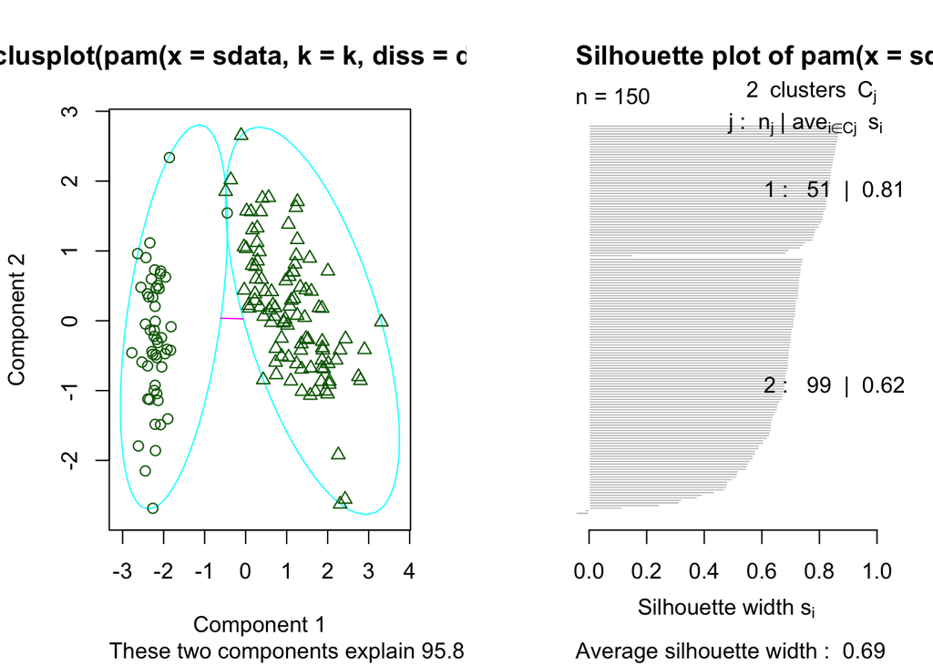

```r
layout(matrix(c(1,2),1,2))
plot(pamk.result$pamobject)
```

```r
layout(matrix(1))
```

在 silhouette 图中， $s_i$ 越靠近1表示聚类越好，若有负数，则表明有误分类的。

下面我们用 `pam()` 函数手动指定聚类个数：

```r
library(cluster)
pam.result <- pam(iris2, 3)
table(pam.result$clustering, iris$Species)
```

```
##
##     setosa versicolor virginica
##   1     50          0         0
##   2      0         48        14
##   3      0          2        36
```

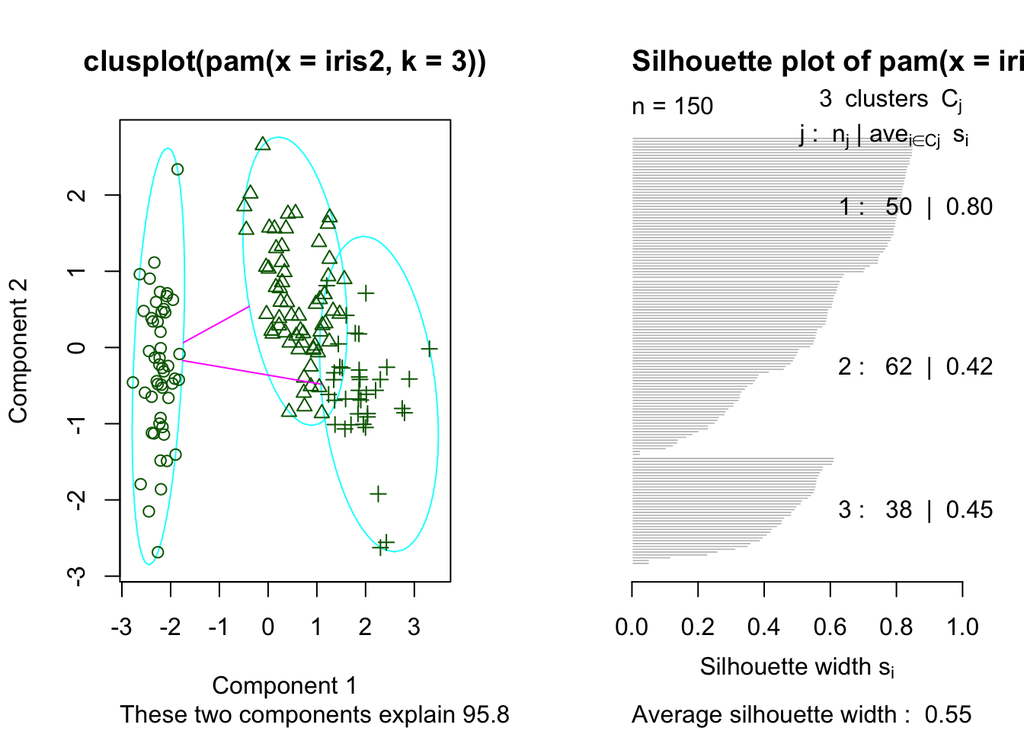

```r
layout(matrix(c(1,2),1,2))
plot(pam.result)
```

```r
layout(matrix(1))
```

# 分层聚类（系统聚类法）

基本思想：设共有个 $n$ 个样本：  
1. 一开始将每个样本单独作为以类（类与类之间的距离就是样本之间的距离）  
2. 找出距离最近的两类将其合并为一类，如此反复，知道合为一个类

要知道分成 $g$ 个类的结果，可以在聚类图中与 $g$ 条竖线相交的高度处画一条水平线。 $g$ 条竖线对应 $g$ 个类。

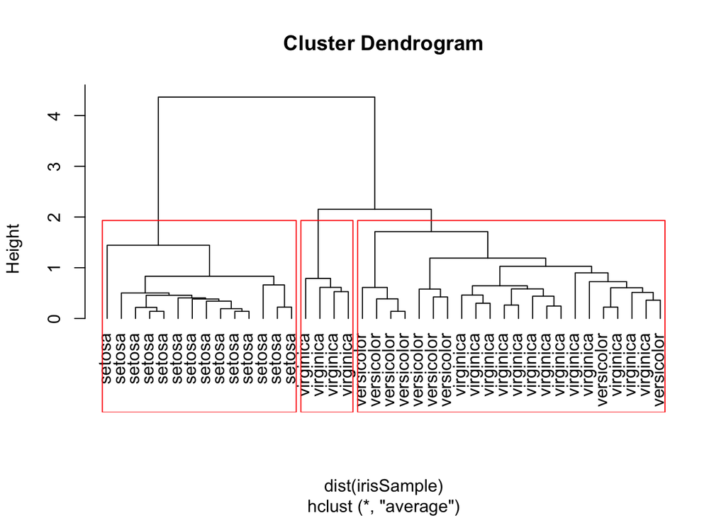

```r
idx <- sample(1:nrow(iris), 40)
irisSample <- iris[idx,]
irisSample$Species <- NULL
hc <- hclust(dist(irisSample), method="ave")
plot(hc, hang = -1, labels=iris$Species[idx])
rect.hclust(hc, k=3)
```

```r
groups <- cutree(hc, k=3)
```

# 基于密度的聚类

The idea of density-based clustering is to group objects into one cluster if they are connected to one another by densely populated area. 如果点 $\alpha$ 的附近的点的数目不小于 MinPts ，则 $\alpha$ 是一个稠密点，它附近的点都可以称作是从 $\alpha$ 点 *density-reachable*，并且这些点都可以和 $\alpha$ 一样放入相同的聚集。

```r
library(fpc)
iris2 <- iris[-5]
ds <- dbscan(iris2, eps=0.42, MinPts=5)
table(ds$cluster, iris$Species) # 其中的0表示噪声或者离异点，在图中是由黑色表示点
```

```
##
##     setosa versicolor virginica
##   0      2         10        17
##   1     48          0         0
##   2      0         37         0
##   3      0          3        33
```

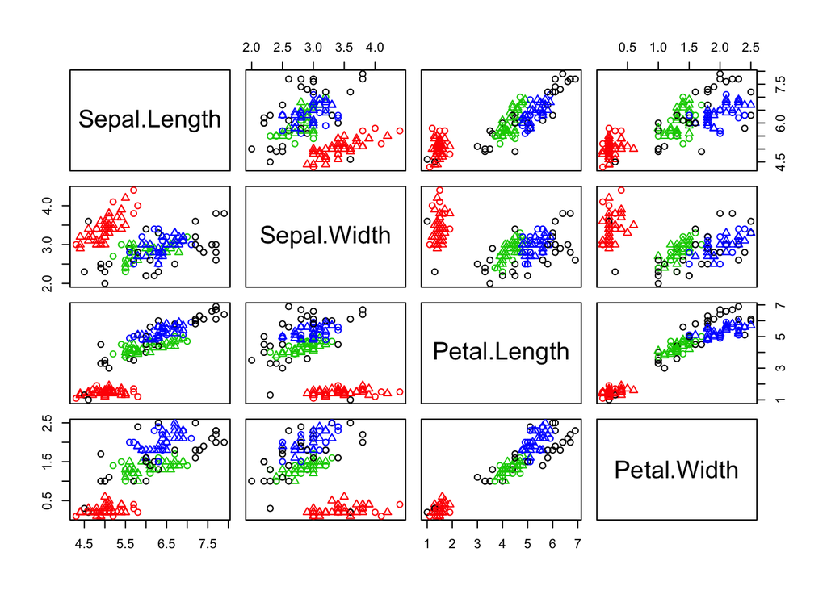

```r
plot(ds, iris2)
```

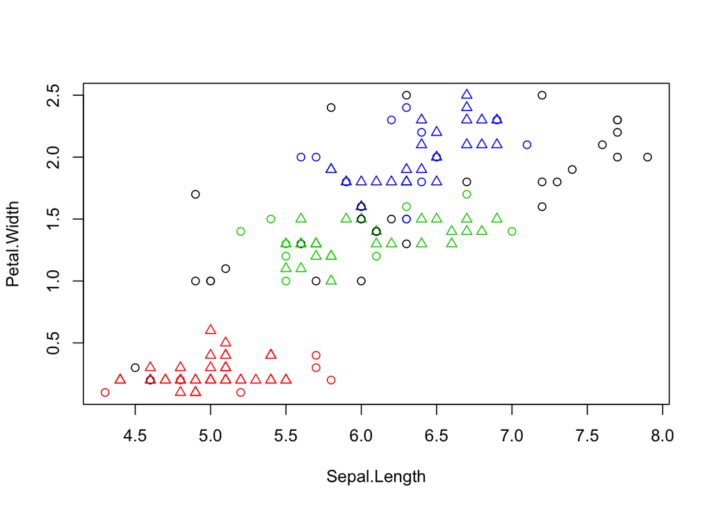

```r
plot(ds, iris2[c(1,4)])
```

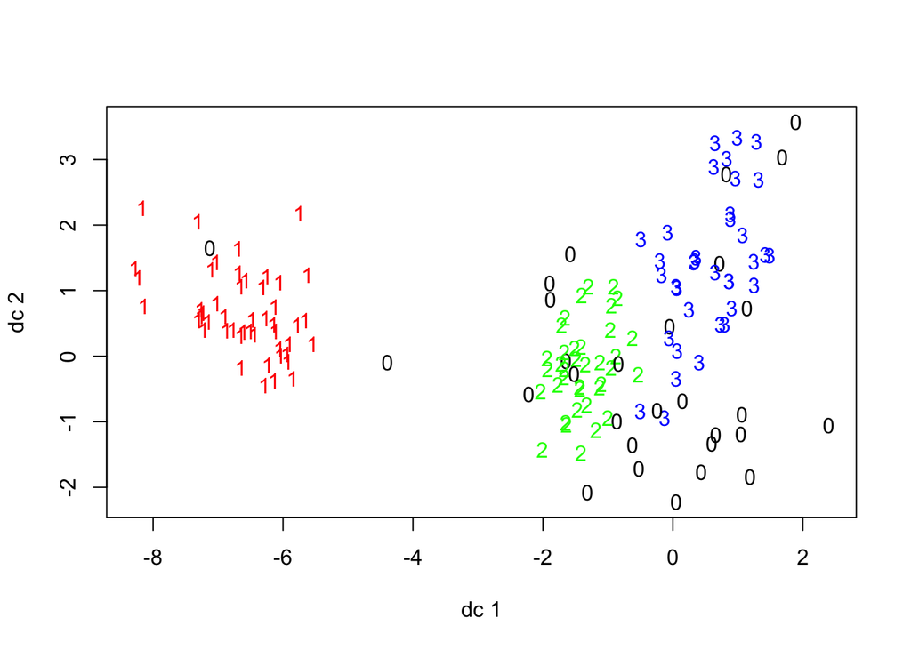

```r
plotcluster(iris2, ds$cluster)
```

标记新数据：

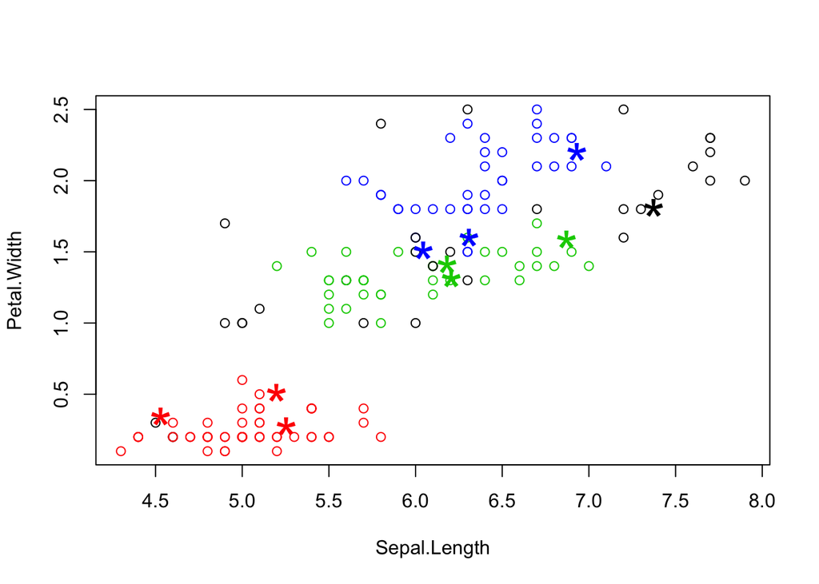

```r
set.seed(435)
idx <- sample(1:nrow(iris), 10)
newData <- iris[idx,-5]
newData <- newData + matrix(runif(10*4, min=0, max=0.2), nrow=10, ncol=4)
myPred <- predict(ds, iris2, newData)
plot(iris2[c(1,4)], col=1+ds$cluster)
points(newData[c(1,4)], pch="*", col=1+myPred, cex=3)
```

```r
table(myPred, iris$Species[idx])
```

```
##
## myPred setosa versicolor virginica
##      0      0          0         1
##      1      3          0         0
##      2      0          3         0
##      3      0          1         2
```